# v0.4.2 exploration gallery

Made 2026-11-26 15:52 PST by `workflow/08_figures/model_figures.py gallery` (branch paper/model-figures, 7aea31dd). Exploration only: not paper figures.

**Model** `/wd1/mdenolle_data/tomo_v1/models/cascadia_obs_tomo/v0.4.2.nc` · cascadia_obs_tomo.v0.4.2 · data revision r0.4.2 · sha256 `45880409101f5d94`  
cascadia_obs_tomo v0.4.2: v0.4.1 (re-timed picks, D-B081 floor in the inversion) with the self-paired catalog differential times of the mendocino_gorda_c, blanco and washington tiles removed (8 events paired with themselves, read by tomoDD as absolute times of 0 s) and those tiles re-inverted with the patched tomoDD-SE (stable sph2car/car2sph near the tile centre axis), D-B099; product as D-B076: medium (rock / water / air at the D-B068 merged surface), D-B073 shallow-crust node rule, Vp_tomography / Vs_tomography = the inversion values

**Grid** 118 latitudes 38.9–50.6°N (0.1°) × 94 longitudes -131.75–-120.125° (0.125°) × 21 depths (km below sea level, uneven): -3, -1, 1, 3, 5, 7, 9, 12, 15, 18, 21, 25, 29, 34, 40, 47, 55, 65, 80, 100, 125. Node spacing about 11 km N–S and 9–10 km E–W.

**Shown cells** (mask `either`): rock nodes only (`medium = 0`; nothing above the seafloor or ground) that are **checkerboard-resolved** (`resolution_p/s > 0`, D-B018: local correlation ≥ 0.7 and amplitude ≥ 0.5, finest of 40/60/100 km cells) **or well sampled** (`DWS ≥ 100`); P for Vp and dVp, S for Vs and dVs, both for Vp/Vs; and data-derived (`tile_weight > 0`; for Vs also `vs_reverted = 0` and not a D-B073 shallow-crust node). **Which rule passes**: cells inside the black outline are checkerboard-resolved; the rest pass on DWS only. The checkerboard-resolved set is small (table) and empty at 21, 25 and 34–60 km, so those depths are DWS-only. Between nodes: multilinear interpolation over shown nodes only, drawn only where the nearest node is shown (no value is made from a masked node).

**Colour** (D-B104; palette_sheet.html): Crameri batlow reversed for Vp and Vs (slow warm, fast cool), roma reversed for Vp/Vs (centred on 1.75, high warm), vik reversed for dVp and dVs (centred on 0, slow warm). Maps: Vp and Vs centred on the median of the inverted rock nodes of that depth (tile_weight > 0, shown or not; range per depth from the 98th percentile of the shown nodes, on each colour bar); Vp/Vs 1.60–1.90; dVp and dVs ±8 % (change from the 3-D starting model, not from a 1-D average). Contours every 0.25 km/s (Vp), 0.15 km/s (Vs), 0.05 (Vp/Vs), 2 % (dV); sections every 0.5 / 0.3 km/s, Vp 4.0–8.4, Vs 2.2–4.8 km/s.

**Overlays**: catalogue `/wd1/mdenolle_data/catalog_v6/v6.0/cascadia_catalog_v6.0.csv`, tiers ABC (139,247 of 172,342 events), maps: events between the mid-depths to the neighbouring nodes; sections: within ±10 km. Stations: ver5 table (`in_ver5`, ▲ land, ▼ ocean bottom). Coast: GMT high resolution. Plate boundaries and trench: PB2002 (Bird 2003). Slab2 top: `/home/mdenolle/cascadia_obs_ensemble/data/slab2/cas_slab2_dep.xyz`. Topography/bathymetry: GMT earth_relief 01m. Missing inputs:

- none

**Node counts per depth** (rock nodes, checkerboard-resolved, DWS ≥ 100, shown)**

| depth_km | rock | checker_P | checker_S | DWS_P>=100 | DWS_S>=100 | shown_Vp | shown_Vs | shown_VpVs |
| --- | --- | --- | --- | --- | --- | --- | --- | --- |
| -3.0 | 1 | 0 | 0 | 0 | 0 | 0 | 0 | 0 |
| -1.0 | 1777 | 0 | 0 | 4 | 0 | 4 | 0 | 0 |
| 1.0 | 5060 | 20 | 0 | 88 | 10 | 88 | 10 | 10 |
| 3.0 | 8586 | 38 | 0 | 119 | 13 | 119 | 13 | 13 |
| 5.0 | 11092 | 51 | 0 | 169 | 23 | 154 | 23 | 23 |
| 7.0 | 11092 | 52 | 1 | 241 | 33 | 192 | 34 | 33 |
| 9.0 | 11092 | 21 | 0 | 408 | 64 | 303 | 57 | 57 |
| 12.0 | 11092 | 4 | 1 | 637 | 119 | 485 | 91 | 86 |
| 15.0 | 11092 | 256 | 188 | 780 | 191 | 794 | 290 | 282 |
| 18.0 | 11092 | 313 | 110 | 793 | 218 | 812 | 277 | 266 |
| 21.0 | 11092 | 0 | 0 | 746 | 158 | 619 | 125 | 125 |
| 25.0 | 11092 | 0 | 0 | 672 | 132 | 571 | 110 | 110 |
| 29.0 | 11092 | 133 | 20 | 471 | 109 | 450 | 114 | 114 |
| 34.0 | 11092 | 0 | 0 | 260 | 14 | 204 | 13 | 13 |
| 40.0 | 11092 | 0 | 0 | 48 | 0 | 39 | 0 | 0 |
| 47.0 | 11092 | 0 | 0 | 10 | 0 | 10 | 0 | 0 |
| 55.0 | 11092 | 0 | 0 | 7 | 0 | 7 | 0 | 0 |

## Map slices (every node depth to 60 km)

Columns: Vp, Vs, Vp/Vs, dVp, dVs. Stations on the Vp panel. Dots: events in the depth layer of the node.

### -3 km

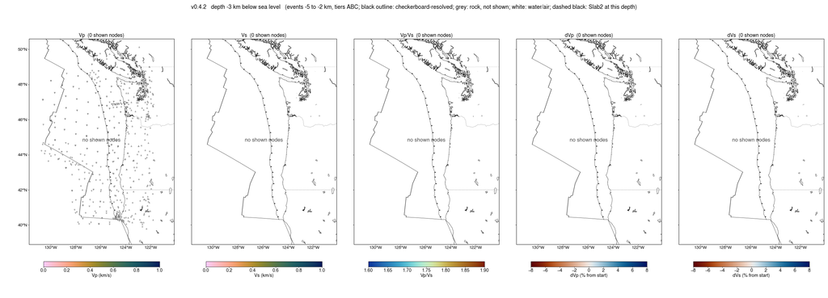

### -1 km

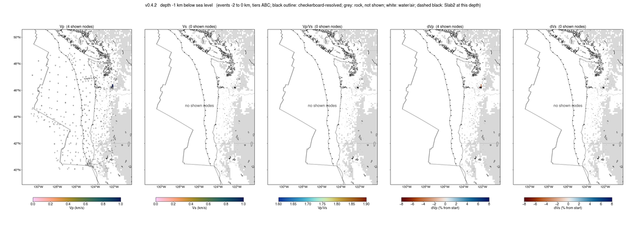

### 1 km

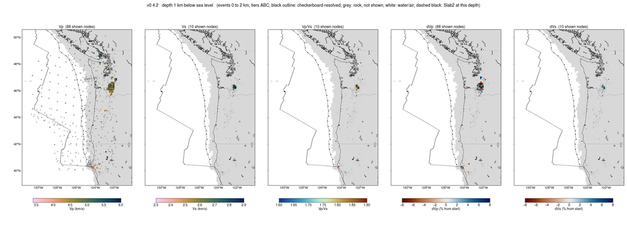

### 3 km

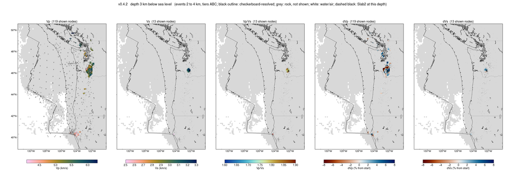

### 5 km

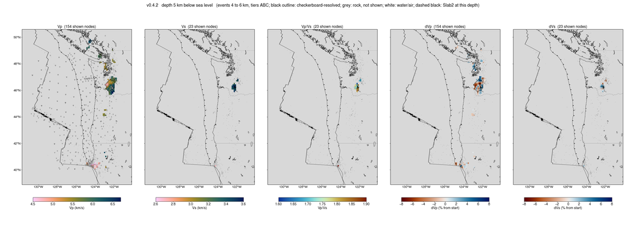

### 7 km

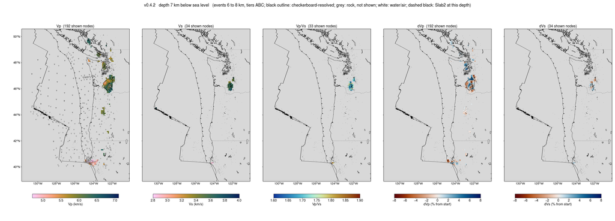

### 9 km

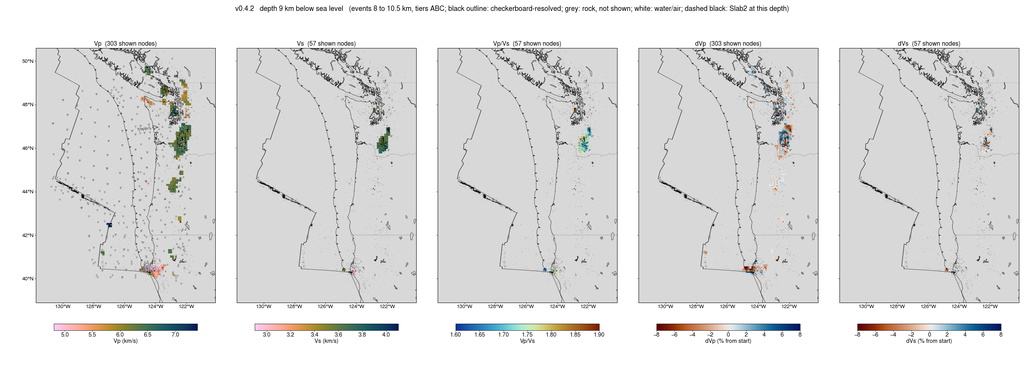

### 12 km

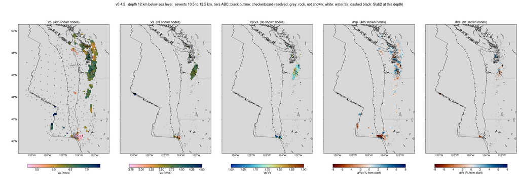

### 15 km

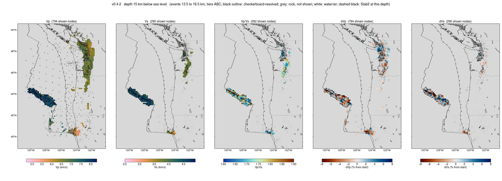

### 18 km

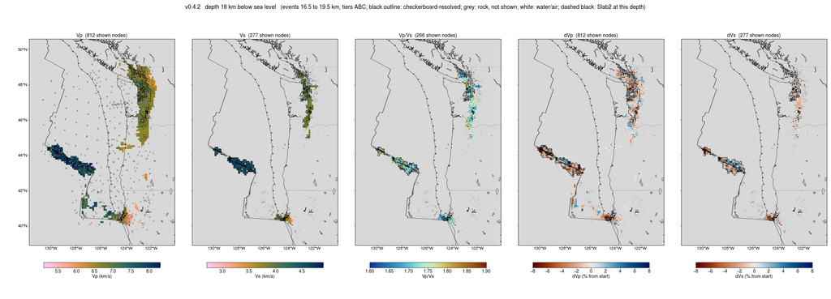

### 21 km

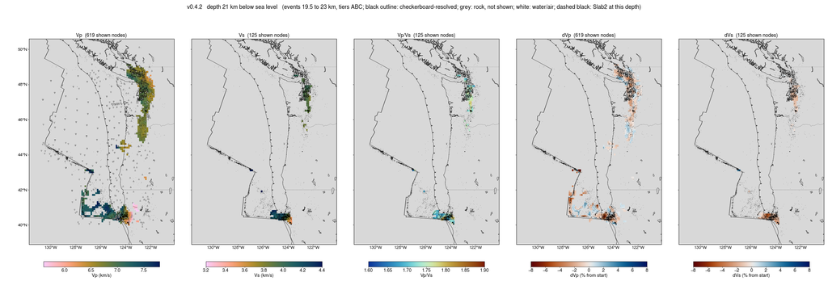

### 25 km

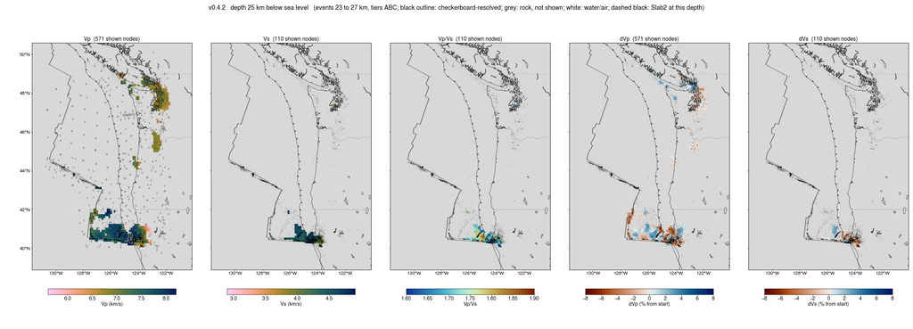

### 29 km

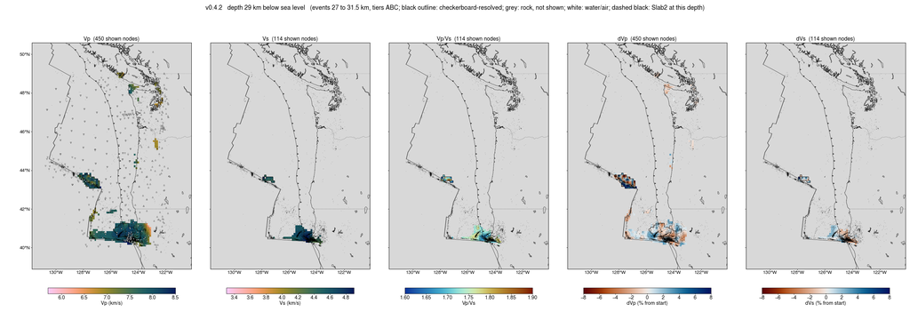

### 34 km

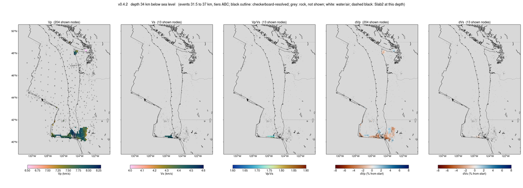

### 40 km

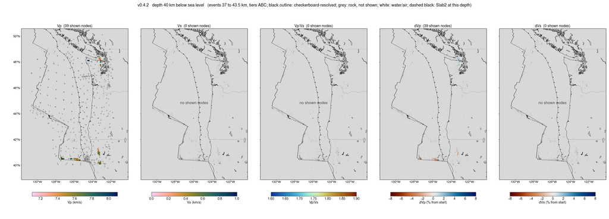

### 47 km

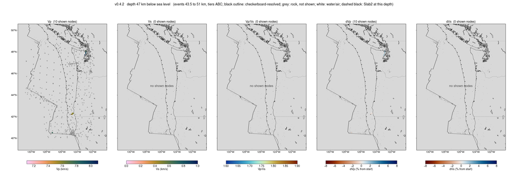

### 55 km

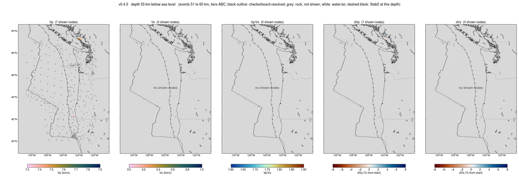

## Cross-sections

Top strip: topography/bathymetry (earth_relief 01m). Panels: Vp, Vs, Vp/Vs; water light blue; air white. West or south on the left.

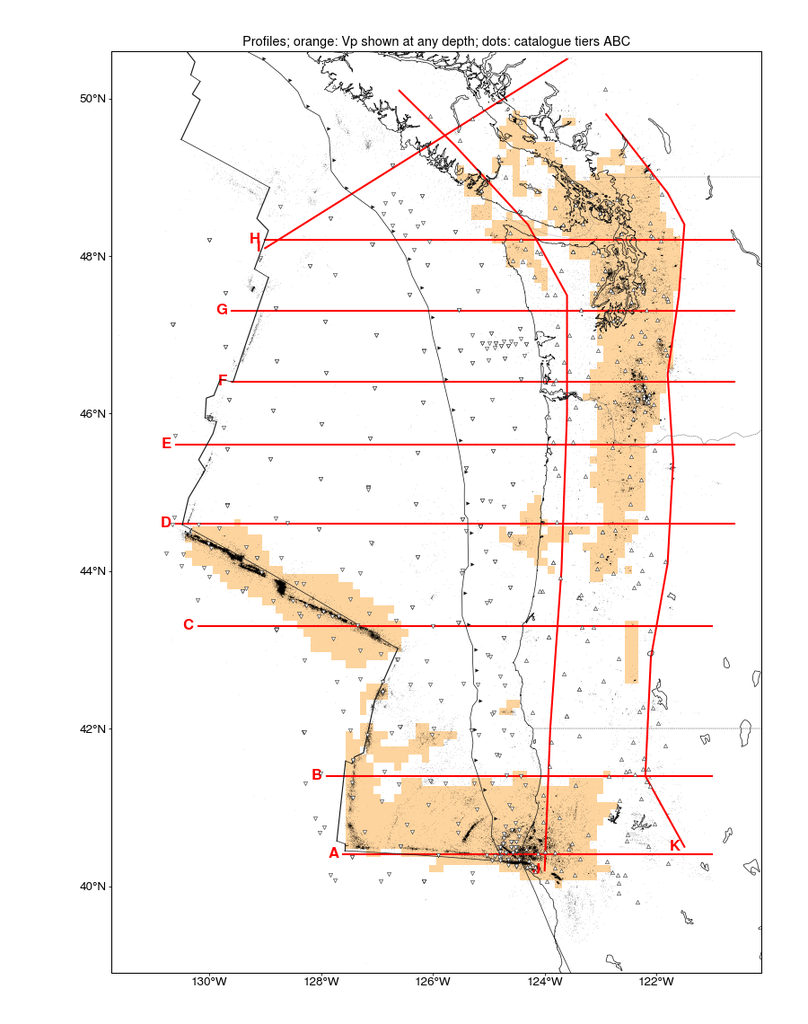

### A: Mendocino 40.4N

vertices (lon, lat): (-127.6, 40.4), (-121, 40.4)

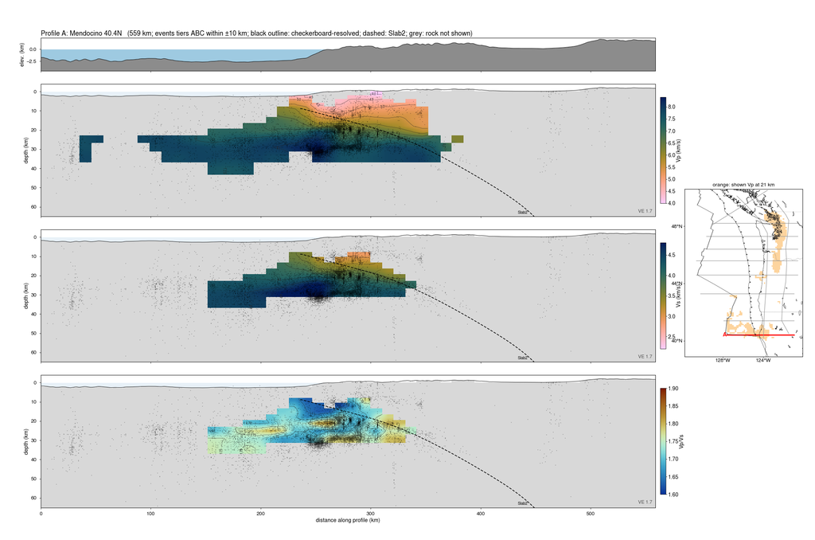

### B: Gorda 41.4N

vertices (lon, lat): (-127.9, 41.4), (-121, 41.4)

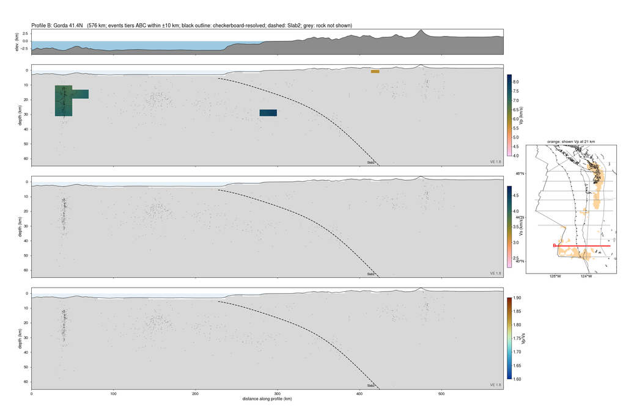

### C: Blanco / S. Oregon 43.3N

vertices (lon, lat): (-130.2, 43.3), (-121, 43.3)

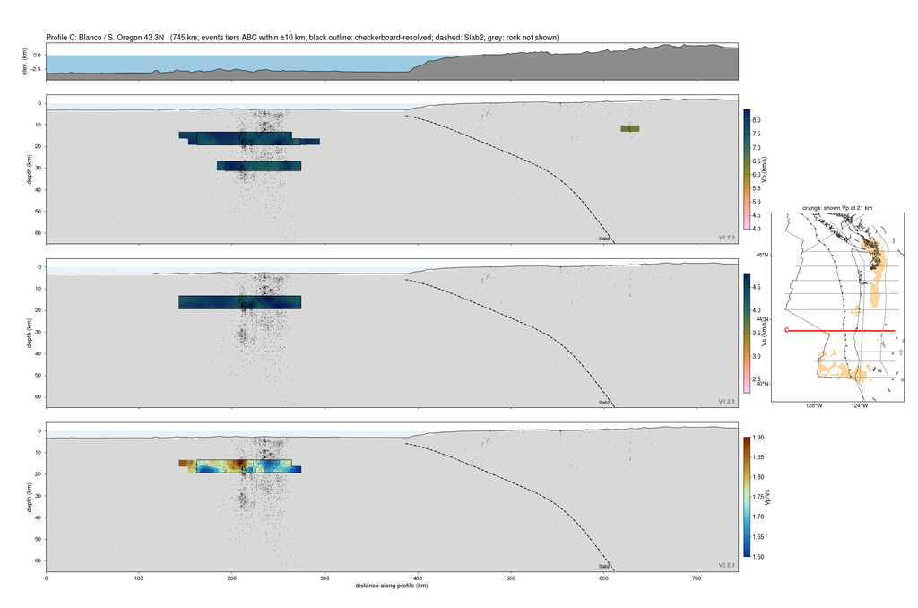

### D: Central Oregon 44.6N

vertices (lon, lat): (-130.6, 44.6), (-120.6, 44.6)

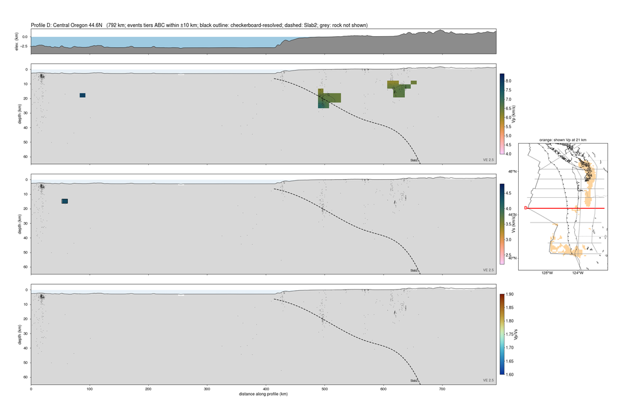

### E: N. Oregon 45.6N

vertices (lon, lat): (-130.6, 45.6), (-120.6, 45.6)

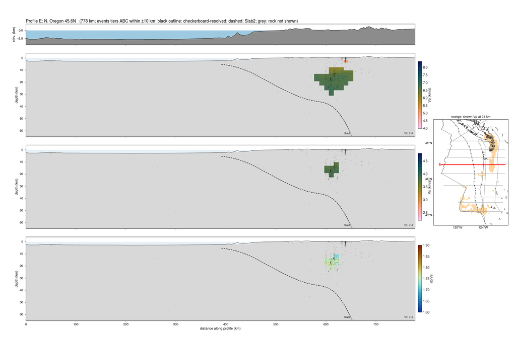

### F: S. Washington 46.4N

vertices (lon, lat): (-129.6, 46.4), (-120.6, 46.4)

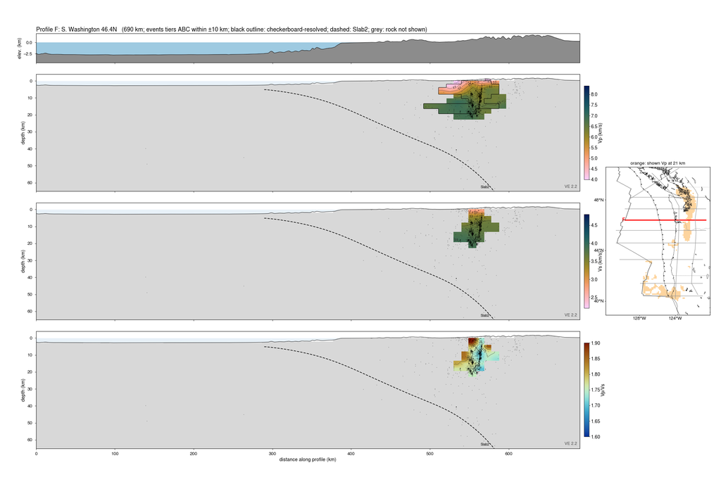

### G: Washington 47.3N

vertices (lon, lat): (-129.6, 47.3), (-120.6, 47.3)

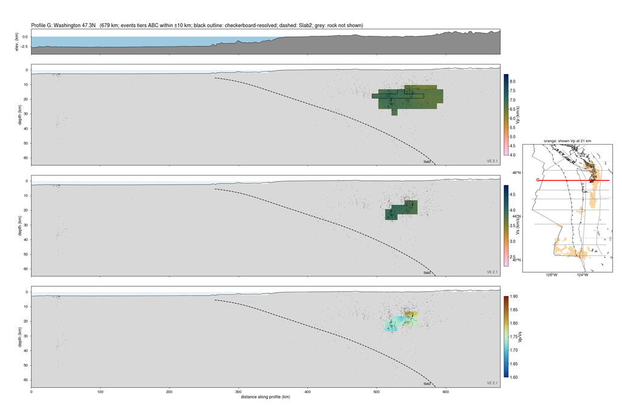

### H: Olympics / Juan de Fuca 48.2N

vertices (lon, lat): (-129, 48.2), (-120.6, 48.2)

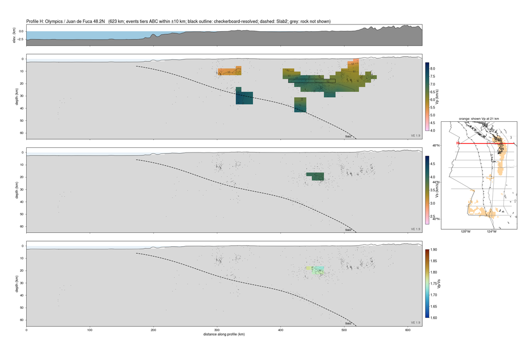

### I: Vancouver Island (N55E)

vertices (lon, lat): (-129, 48.1), (-123.6, 50.5)

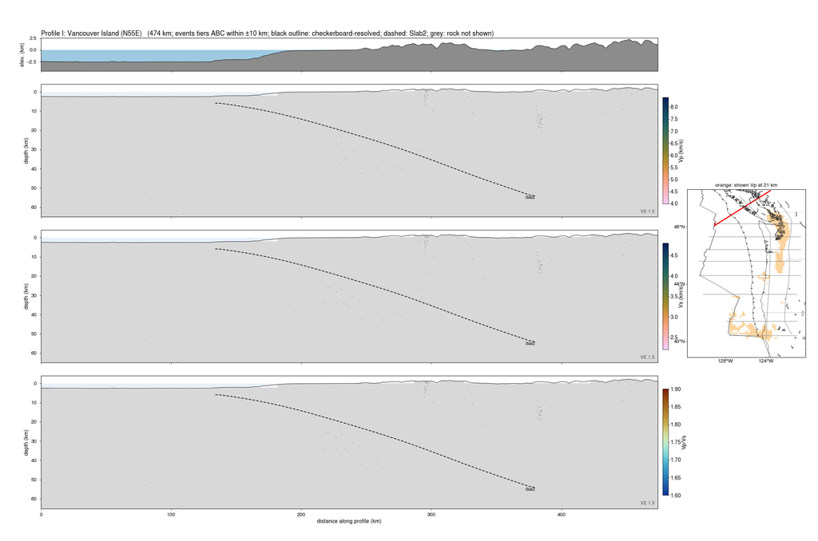

### J: Forearc (Coast Ranges, margin-parallel)

vertices (lon, lat): (-124, 40.2), (-123.9, 42), (-123.7, 44), (-123.6, 46), (-123.6, 47.5), (-124.3, 48.4), (-125.6, 49.4), (-126.6, 50.1)

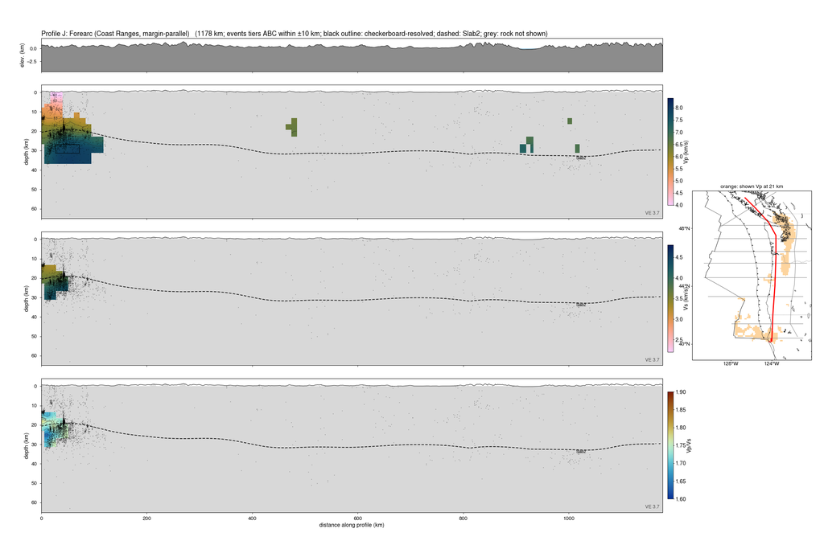

### K: Arc (volcanic front, margin-parallel)

vertices (lon, lat): (-121.5, 40.5), (-122.2, 41.4), (-122.1, 42.9), (-121.8, 44.1), (-121.7, 45.4), (-121.8, 46.5), (-121.6, 47.5), (-121.5, 48.4), (-121.8, 48.8), (-122.9, 49.8)

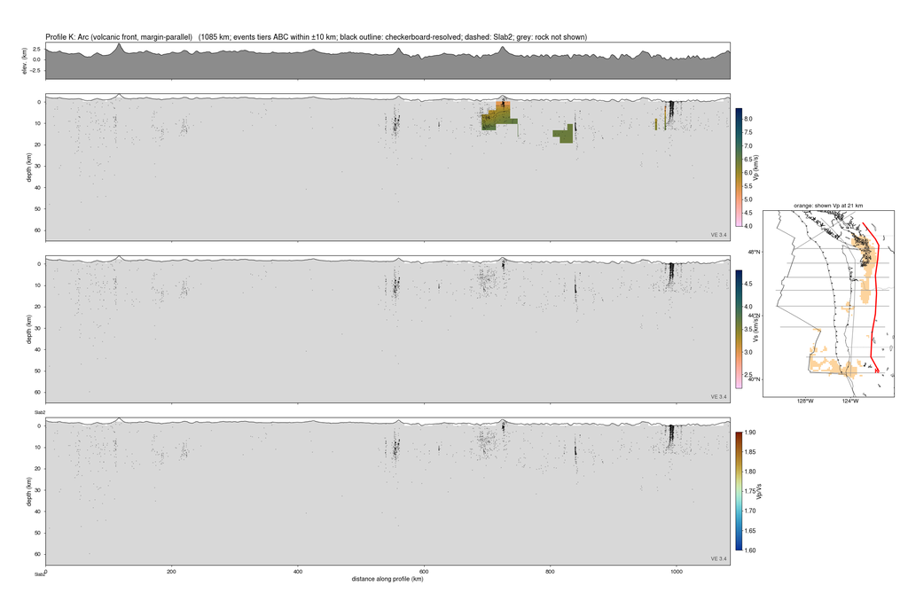

## Resolution

Finest resolved checkerboard cell (P, S; D-B018 per-tile masks merged as the finest over the covering tiles; blank = not resolved) and the merge-weighted derivative weight sum (P, S; white contour = 100). Grey: rock nodes with no value.

### -3 km

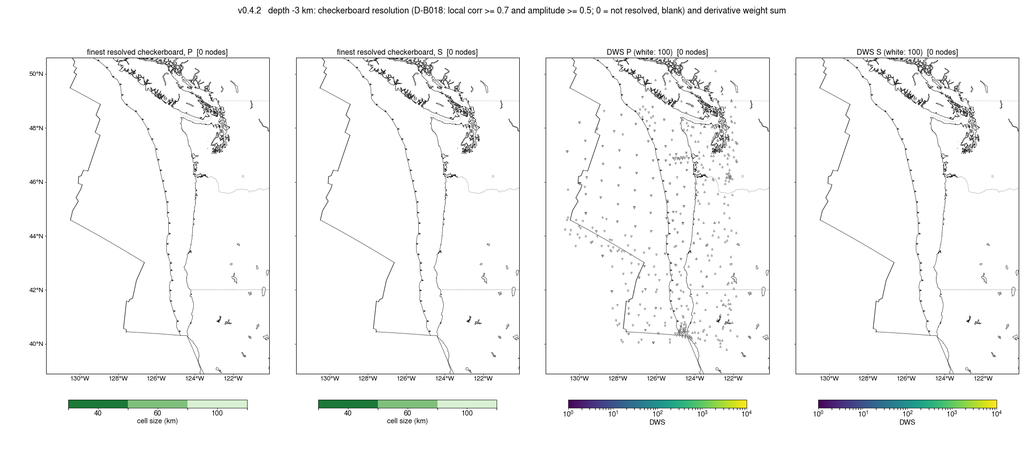

### -1 km

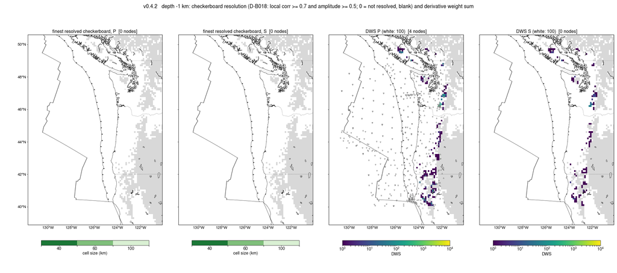

### 1 km

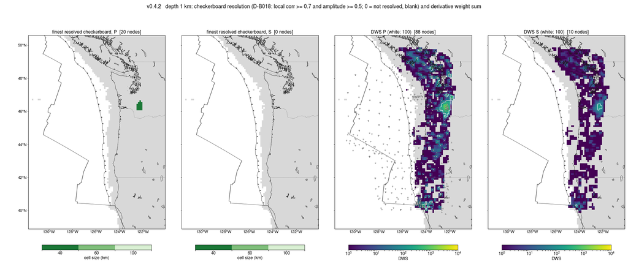